# Matching examples

Matthew Upson

9 June 2016

```r
knitr::opts_chunk$set(
  warning = FALSE,
  message = FALSE,
  error = FALSE
  )
```

# Matching methods

## 1: Propensity score matching

The example shown here is reproduced from [Sekhon (2011)](http://sekhon.berkeley.edu/papers/MatchingJSS.pdf). See also teh package homepage: http://sekhon.berkeley.edu/matching/.

```r
# Load required packages:

library(dplyr)
library(Matching)
library(ggplot2)
library(cem)
library(magrittr)
```

This example uses the Lalonde dataset from the Matching package:

```r
# Load the lalonde data

data("lalonde")

summary(lalonde)
```

```
##       age             educ          black             hisp
##  Min.   :17.00   Min.   : 3.0   Min.   :0.0000   Min.   :0.00000
##  1st Qu.:20.00   1st Qu.: 9.0   1st Qu.:1.0000   1st Qu.:0.00000
##  Median :24.00   Median :10.0   Median :1.0000   Median :0.00000
##  Mean   :25.37   Mean   :10.2   Mean   :0.8337   Mean   :0.08764
##  3rd Qu.:28.00   3rd Qu.:11.0   3rd Qu.:1.0000   3rd Qu.:0.00000
##  Max.   :55.00   Max.   :16.0   Max.   :1.0000   Max.   :1.00000
##     married           nodegr           re74              re75
##  Min.   :0.0000   Min.   :0.000   Min.   :    0.0   Min.   :    0
##  1st Qu.:0.0000   1st Qu.:1.000   1st Qu.:    0.0   1st Qu.:    0
##  Median :0.0000   Median :1.000   Median :    0.0   Median :    0
##  Mean   :0.1685   Mean   :0.782   Mean   : 2102.3   Mean   : 1377
##  3rd Qu.:0.0000   3rd Qu.:1.000   3rd Qu.:  824.4   3rd Qu.: 1221
##  Max.   :1.0000   Max.   :1.000   Max.   :39570.7   Max.   :25142
##       re78            u74              u75             treat
##  Min.   :    0   Min.   :0.0000   Min.   :0.0000   Min.   :0.0000
##  1st Qu.:    0   1st Qu.:0.0000   1st Qu.:0.0000   1st Qu.:0.0000
##  Median : 3702   Median :1.0000   Median :1.0000   Median :0.0000
##  Mean   : 5301   Mean   :0.7326   Mean   :0.6494   Mean   :0.4157
##  3rd Qu.: 8125   3rd Qu.:1.0000   3rd Qu.:1.0000   3rd Qu.:1.0000
##  Max.   :60308   Max.   :1.0000   Max.   :1.0000   Max.   :1.0000
```

```r
str(lalonde)
```

```
## 'data.frame':    445 obs. of  12 variables:
##  $ age    : int  37 22 30 27 33 22 23 32 22 33 ...
##  $ educ   : int  11 9 12 11 8 9 12 11 16 12 ...
##  $ black  : int  1 0 1 1 1 1 1 1 1 0 ...
##  $ hisp   : int  0 1 0 0 0 0 0 0 0 0 ...
##  $ married: int  1 0 0 0 0 0 0 0 0 1 ...
##  $ nodegr : int  1 1 0 1 1 1 0 1 0 0 ...
##  $ re74   : num  0 0 0 0 0 0 0 0 0 0 ...
##  $ re75   : num  0 0 0 0 0 0 0 0 0 0 ...
##  $ re78   : num  9930 3596 24910 7506 290 ...
##  $ u74    : int  1 1 1 1 1 1 1 1 1 1 ...
##  $ u75    : int  1 1 1 1 1 1 1 1 1 1 ...
##  $ treat  : int  1 1 1 1 1 1 1 1 1 1 ...
```

```r
## outcome of interest and treatment indicator
## Re-label for later use

Y <- lalonde$re78
Tr <- lalonde$treat

# estimate first propensity model using a glm
```

The first substantice step is define a model for our glm. Note that this is a step that is peculiar to PSM compared to other matching methods, and is one reason why I believe it should not be favoured. Matching will only be as good as the fit of the model that is chosen, adding an additional level of complexity to the process.

```r
glm_formula <- formula(Tr ~
    age + educ + black +
    hisp + married + nodegr +
    re74 + re75
    )

## You can define the formula in the glm call istelf, but there are situations
## where it is preferable not to.


system.time(
glm1 <- glm(
  glm_formula,
  family = binomial,
  data = lalonde
)
)
```

```
##    user  system elapsed
##   0.006   0.000   0.007
```

We can check the outcome of the model as usual with:

```r
summary(glm1)
```

```
##
## Call:
## glm(formula = glm_formula, family = binomial, data = lalonde)
##
## Deviance Residuals:
##     Min       1Q   Median       3Q      Max
## -1.4358  -0.9904  -0.9071   1.2825   1.6946
##
## Coefficients:
##               Estimate Std. Error z value Pr(>|z|)
## (Intercept)  1.178e+00  1.056e+00   1.115  0.26474
## age          4.698e-03  1.433e-02   0.328  0.74297
## educ        -7.124e-02  7.173e-02  -0.993  0.32061
## black       -2.247e-01  3.655e-01  -0.615  0.53874
## hisp        -8.528e-01  5.066e-01  -1.683  0.09228 .
## married      1.636e-01  2.769e-01   0.591  0.55463
## nodegr      -9.035e-01  3.135e-01  -2.882  0.00395 **
## re74        -3.161e-05  2.584e-05  -1.223  0.22122
## re75         6.161e-05  4.358e-05   1.414  0.15744
## ---
## Signif. codes:  0 '***' 0.001 '**' 0.01 '*' 0.05 '.' 0.1 ' ' 1
##
## (Dispersion parameter for binomial family taken to be 1)
##
##     Null deviance: 604.20  on 444  degrees of freedom
## Residual deviance: 587.22  on 436  degrees of freedom
## AIC: 605.22
##
## Number of Fisher Scoring iterations: 4
```

But in many respects, this is less important than checking the balance of the matching process itself, which we will do later

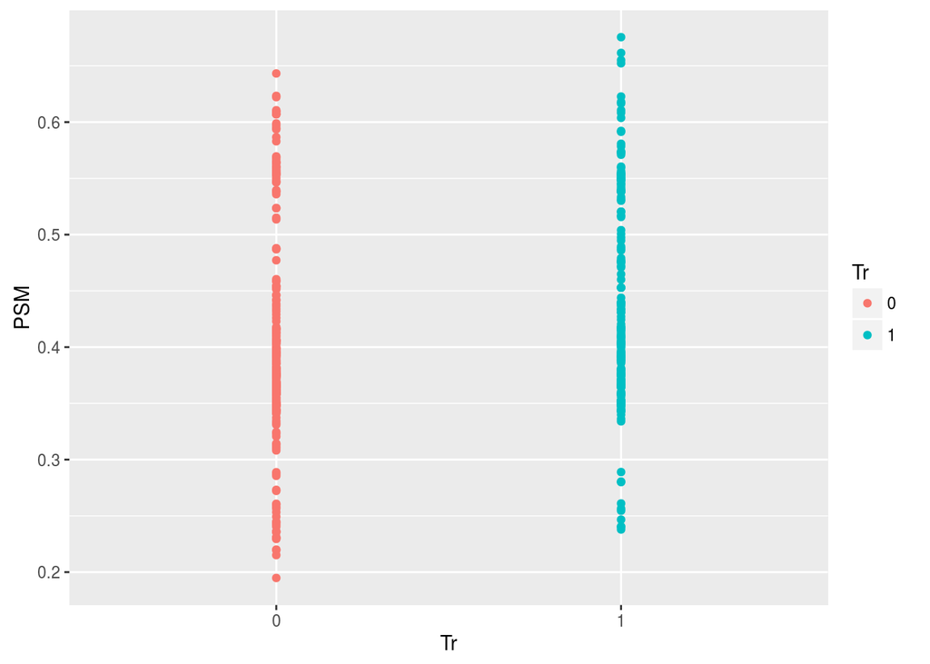

```r
## Now one to one matching with replacement. We will use the fitted values (the
## propensity score) from the glm as argument X within the Match call.

## These are values between 0 and 1. Just out of interest, we can plot these
## out. This gives us an indication of how the propensity scores match across
## treatments.

data_frame(
  Tr = factor(Tr),
  PSM = glm1$fitted.values
) %>%
  ggplot +
  aes(
    y = PSM,
    x = Tr,
    group = Tr,
    colour = Tr
  ) +
  geom_point()
```

Now run the Matching itself based on the above glm.

```r
glm1$fitted %>% unname %>% head
```

```
## [1] 0.4021026 0.2466787 0.5594794 0.3526728 0.4096518 0.3802885
```

```r
system.time(
rr1 <- Match(
  Y = Y,
  Tr = Tr,
  # Take the fitted values
  X = glm1$fitted.values,
  # See ?Match. Running on a DfE machien with a large dataset will probably
  # require ties to be broken with ties = FALSE. This means that a random match
  # will be chosen if multiple possibilities exist
  ties = TRUE,
  # See Sekhon 2011 for an explanation of ATT. In almost all cases, you will
  # want to use ATT.
  estimand = "ATT",
  # caliper sets the threshold to allow matching. If a potential match is beyond
  # the threshold caliper, then it is not included as a match. This can take
  # either a scalar or a vector of scalars equal in length to the number of
  # input varoables. In general I haven't tended to play with this, but it could
  # be used to improve matching outcomes. Note that the caliper itself is a
  # proportion of the standard deviation of the given variable. See ?mMtch
  caliper = 0.25
)
)
```

```
##    user  system elapsed
##   0.009   0.003   0.027
```

```r
summary(rr1)
```

```
##
## Estimate...  2570.1
## AI SE......  796.06
## T-stat.....  3.2285
## p.val......  0.0012443
##
## Original number of observations..............  445
## Original number of treated obs...............  185
## Matched number of observations...............  184
## Matched number of observations  (unweighted).  343
##
## Caliper (SDs)........................................   0.25
## Number of obs dropped by 'exact' or 'caliper'  1
```

```r
## Now check the balance of our propensity score model. Note that this model uses many more variables than the model itself.

system.time(
MatchBalance(
  Tr ~
    age + I(age^2) + educ +
    I(educ^2) + black + hisp +
    married + nodegr + re74 +
    I(re74^2) + re75 + I(re75^2) +
    u74 + u75 + I(re74 * re75) +
    I(age * nodegr) + I(educ * re74) +
    I(educ * re75),
  match.out = rr1,
  nboots = 1000,
  data = lalonde
)
)
```

```
##
## ***** (V1) age *****
##                        Before Matching        After Matching
## mean treatment........     25.816             25.837
## mean control..........     25.054             25.663
## std mean diff.........     10.655             2.4225
##
## mean raw eQQ diff.....    0.94054            0.73178
## med  raw eQQ diff.....          1                  0
## max  raw eQQ diff.....          7                  9
##
## mean eCDF diff........   0.025364           0.021684
## med  eCDF diff........   0.022193           0.020408
## max  eCDF diff........   0.065177           0.058309
##
## var ratio (Tr/Co).....     1.0278             1.0849
## T-test p-value........    0.26594            0.79143
## KS Bootstrap p-value..      0.537              0.396
## KS Naive p-value......     0.7481            0.60432
## KS Statistic..........   0.065177           0.058309
##
##
## ***** (V2) I(age^2) *****
##                        Before Matching        After Matching
## mean treatment........     717.39             718.66
## mean control..........     677.32             705.72
## std mean diff.........     9.2937             2.9957
##
## mean raw eQQ diff.....     56.076             46.679
## med  raw eQQ diff.....         43                  0
## max  raw eQQ diff.....        721                909
##
## mean eCDF diff........   0.025364           0.021684
## med  eCDF diff........   0.022193           0.020408
## max  eCDF diff........   0.065177           0.058309
##
## var ratio (Tr/Co).....     1.0115             1.0075
## T-test p-value........    0.33337            0.75595
## KS Bootstrap p-value..      0.537              0.396
## KS Naive p-value......     0.7481            0.60432
```

[output cut: 311 more lines]

```
## med  eCDF diff........   0.064293           0.046647
## max  eCDF diff........     0.1052           0.099125
##
## var ratio (Tr/Co).....     1.1901            0.62201
## T-test p-value........    0.35903           0.095756
## KS Bootstrap p-value..      0.062              0.007
## KS Naive p-value......    0.18269           0.068758
## KS Statistic..........     0.1052           0.099125
##
##
## Before Matching Minimum p.value: 0.0020368
## Variable Name(s): nodegr  Number(s): 8
##
## After Matching Minimum p.value: 0.002
## Variable Name(s): re74 I(re74^2) I(educ * re74)  Number(s): 9 10 17
```

```
##    user  system elapsed
##   7.695   0.968   9.018
```

```r
## Consider nodegr See summary statistics. First set shows means for treatment
## and control and mean difference in standard deviation. Second set shows
## statistics based on the raw empirical-QQ plots, and hence are in the same
## scale as the variable being tested. The third set of statistics are the same
## empirical QQ statistics, but this time standardised. Finally there is the
## variance ration - the closer this is to 1, the better the match, and a
## p-value from a t-test of the difference of the means (not paired). For nodegr
## there were significant differences between treatments before and after
## matching.
```

## 2: Mahalanobis distance

```r
### Try matching again with Mahalanobis distance

X <- lalonde %>%
  dplyr::select(
    age,
    educ,
    black,
    hisp,
    married,
    nodegr,
    re74,
    re75
    )
```

Now one to one matching with replacement

```r
system.time(
rr2 <- Match(
  Y = Y,
  Tr = Tr,
  X = X,
  # Weight = 2 will use Mahalanobis distance as the distance metric
  Weight = 2
  )
)
```

```
##    user  system elapsed
##   0.015   0.065   0.025
```

Now look at the summary

```r
summary(rr2)
```

```
##
## Estimate...  2453.1
## AI SE......  803.76
## T-stat.....  3.052
## p.val......  0.0022732
##
## Original number of observations..............  445
## Original number of treated obs...............  185
## Matched number of observations...............  185
## Matched number of observations  (unweighted).  272
```

Now check match balance

```r
system.time(
MatchBalance(
  Tr ~
    age + I(age^2) + educ +
    I(educ^2) + black + hisp +
    married + nodegr + re74 +
    I(re74^2) + re75 + I(re75^2) +
    u74 + u75 + I(re74 * re75) +
    I(age * nodegr) + I(educ * re74) +
    I(educ * re75),
  match.out = rr2,
  nboots = 1000,
  data = lalonde
)
)
```

```
##
## ***** (V1) age *****
##                        Before Matching        After Matching
## mean treatment........     25.816             25.816
## mean control..........     25.054             24.732
## std mean diff.........     10.655             15.147
##
## mean raw eQQ diff.....    0.94054            0.83456
## med  raw eQQ diff.....          1                  1
## max  raw eQQ diff.....          7                  7
##
## mean eCDF diff........   0.025364           0.025391
## med  eCDF diff........   0.022193           0.025735
## max  eCDF diff........   0.065177           0.055147
##
## var ratio (Tr/Co).....     1.0278             1.1433
## T-test p-value........    0.26594         0.00024726
## KS Bootstrap p-value..      0.507               0.55
## KS Naive p-value......     0.7481            0.80259
## KS Statistic..........   0.065177           0.055147
##
##
## ***** (V2) I(age^2) *****
##                        Before Matching        After Matching
## mean treatment........     717.39             717.39
## mean control..........     677.32             656.23
## std mean diff.........     9.2937             14.184
##
## mean raw eQQ diff.....     56.076              49.32
## med  raw eQQ diff.....         43                 37
## max  raw eQQ diff.....        721                721
##
## mean eCDF diff........   0.025364           0.025391
## med  eCDF diff........   0.022193           0.025735
## max  eCDF diff........   0.065177           0.055147
##
## var ratio (Tr/Co).....     1.0115             1.1742
## T-test p-value........    0.33337          0.0012963
## KS Bootstrap p-value..      0.507               0.55
## KS Naive p-value......     0.7481            0.80259
```

[output cut: 311 more lines]

```
## med  eCDF diff........   0.064293           0.047794
## max  eCDF diff........     0.1052           0.077206
##
## var ratio (Tr/Co).....     1.1901             2.2526
## T-test p-value........    0.35903         0.00010574
## KS Bootstrap p-value..      0.067              0.095
## KS Naive p-value......    0.18269            0.39223
## KS Statistic..........     0.1052           0.077206
##
##
## Before Matching Minimum p.value: 0.0020368
## Variable Name(s): nodegr  Number(s): 8
##
## After Matching Minimum p.value: 3.3603e-05
## Variable Name(s): re75  Number(s): 11
```

```
##    user  system elapsed
##   6.019   0.838   6.580
```

## 3: Genetic Matching

```r
X <- lalonde %>%
  dplyr::select(
    age, educ, black, hisp, married, nodegr, re74, re75, u74, u75
  )

system.time(
BalanceMatrix <- lalonde %>%
  transmute(
    age, I(age^2), educ, I(educ^2), black, hisp,
    married, nodegr, re74, I(re74^2), re75, I(re75^2),
    u74, u75, I(re74 * re75), I(age * nodegr), I(educ * re74),
    I(educ * re75)
  )
)
```

```
##    user  system elapsed
##   0.006   0.000   0.007
```

```r
system.time(
gen1 <- GenMatch(
  Tr = Tr,
  X = X,
  BalanceMatrix = BalanceMatrix,
  pop.size = 1000
)
)
```

[output not shown]

[output cut: 1238 more lines]

```
##  X[ 2] : 9.849762e+02
##  X[ 3] : 8.455953e+01
##  X[ 4] : 6.142915e+02
##  X[ 5] : 2.468633e+00
##  X[ 6] : 4.388352e+02
##  X[ 7] : 6.002589e+02
##  X[ 8] : 3.454609e+02
##  X[ 9] : 4.074984e+01
##  X[10] : 2.817963e+01
##
## Solution Found Generation 22
## Number of Generations Run 27
##
## Mon Jun 13 20:46:36 2016
## Total run time : 0 hours 6 minutes and 4 seconds
```

```
##    user  system elapsed
## 363.886 348.489 363.783
```

check summary

```r
system.time(
mgen1 <- Match(
  Y = Y,
  Tr = Tr,
  X = X,
  Weight.matrix = gen1
  )
)
```

```
##    user  system elapsed
##   0.004   0.013   0.009
```

```r
system.time(
MatchBalance(
  Tr ~
    age + I(age^2) + educ +
    I(educ^2) + black + hisp +
    married + nodegr + re74 +
    I(re74^2) + re75 + I(re75^2) +
    u74 + u75 + I(re74 * re75) +
    I(age * nodegr) + I(educ * re74) + I(educ * re75),
  data = lalonde,
  match.out = mgen1,
  nboots = 1000
)
)
```

```
##
## ***** (V1) age *****
##                        Before Matching        After Matching
## mean treatment........     25.816             25.816
## mean control..........     25.054             25.651
## std mean diff.........     10.655             2.3042
##
## mean raw eQQ diff.....    0.94054            0.38113
## med  raw eQQ diff.....          1                  0
## max  raw eQQ diff.....          7                  7
##
## mean eCDF diff........   0.025364           0.011199
## med  eCDF diff........   0.022193           0.011321
## max  eCDF diff........   0.065177           0.026415
##
## var ratio (Tr/Co).....     1.0278             1.0113
## T-test p-value........    0.26594            0.43322
## KS Bootstrap p-value..      0.525              0.994
## KS Naive p-value......     0.7481            0.99999
## KS Statistic..........   0.065177           0.026415
##
##
## ***** (V2) I(age^2) *****
##                        Before Matching        After Matching
## mean treatment........     717.39             717.39
## mean control..........     677.32             708.34
## std mean diff.........     9.2937             2.0995
##
## mean raw eQQ diff.....     56.076             24.109
## med  raw eQQ diff.....         43                  0
## max  raw eQQ diff.....        721                721
##
## mean eCDF diff........   0.025364           0.011199
## med  eCDF diff........   0.022193           0.011321
## max  eCDF diff........   0.065177           0.026415
##
## var ratio (Tr/Co).....     1.0115            0.99313
## T-test p-value........    0.33337            0.49924
## KS Bootstrap p-value..      0.525              0.994
## KS Naive p-value......     0.7481            0.99999
```

[output cut: 311 more lines]

```
## med  eCDF diff........   0.064293           0.009434
## max  eCDF diff........     0.1052           0.041509
##
## var ratio (Tr/Co).....     1.1901             1.1787
## T-test p-value........    0.35903            0.76779
## KS Bootstrap p-value..      0.057              0.639
## KS Naive p-value......    0.18269             0.9764
## KS Statistic..........     0.1052           0.041509
##
##
## Before Matching Minimum p.value: 0.0020368
## Variable Name(s): nodegr  Number(s): 8
##
## After Matching Minimum p.value: 0.36661
## Variable Name(s): I(re75^2)  Number(s): 12
```

```
##    user  system elapsed
##   5.445   0.842   6.005
```

```r
summary(mgen1)
```

```
##
## Estimate...  1472.6
## AI SE......  857.57
## T-stat.....  1.7171
## p.val......  0.085954
##
## Original number of observations..............  445
## Original number of treated obs...............  185
## Matched number of observations...............  185
## Matched number of observations  (unweighted).  265
```

## Coarsened Exact Matching (CEM)

```r
X1 <- lalonde %>%
  dplyr::select(
    treat, age, educ, black, hisp,
    married, nodegr, re74, re75, re78
  ) %>%
  mutate(
    black = factor(black),
    hisp = factor(hisp),
    married = factor(married),
    nodegr = factor(nodegr),
    re74,
    re75,
    re78
  )

imbalance(
  group = X1$treat,
  data = dplyr::select(X1,-treat)
)
```

```
##
## Multivariate Imbalance Measure: L1=0.721
## Percentage of local common support: LCS=12.0%
##
## Univariate Imbalance Measures:
##
##            statistic   type         L1 min    25%     50%      75%     max
## age        0.7623701 (diff) 0.00000000   0   1.00    1.00    1.000    -7.0
## educ       0.2574844 (diff) 0.16548857   1   0.00    1.00    1.000     2.0
## black      0.1066238 (Chi2) 0.01632017  NA     NA      NA       NA      NA
## hisp       2.5705629 (Chi2) 0.04823285  NA     NA      NA       NA      NA
## married    0.7277914 (Chi2) 0.03534304  NA     NA      NA       NA      NA
## nodegr     9.4195394 (Chi2) 0.12650728  NA     NA      NA       NA      NA
## re74     -11.4528154 (diff) 0.00000000   0   0.00    0.00 1291.470 -4530.6
## re75     265.1463890 (diff) 0.00000000   0   0.00    0.00 1172.008  2110.2
## re78    1794.3430849 (diff) 0.00000000   0 485.23 1148.73 2358.610 20824.4
```

```r
system.time(
mat <- cem(
  treatment = "treat",
  data = X1,
  drop = "re78",
  eval.imbalance = TRUE
)
)
```

```
##    user  system elapsed
##   0.057   0.000   0.057
```

```r
mat
```

```
##            G0  G1
## All       260 185
## Matched   175 109
## Unmatched  85  76
##
##
## Multivariate Imbalance Measure: L1=0.335
## Percentage of local common support: LCS=38.6%
##
## Univariate Imbalance Measures:
##
##            statistic   type           L1 min 25% 50% 75%      max
## age      -0.04021010 (diff) 0.000000e+00   0   0   0   0    -1.00
## educ     -0.02694309 (diff) 4.345685e-02  -1  -1   0   0     0.00
## black     0.26029290 (Chi2) 6.245005e-17  NA  NA  NA  NA       NA
## hisp      1.11476996 (Chi2) 5.898060e-17  NA  NA  NA  NA       NA
## married   0.01604342 (Chi2) 5.551115e-17  NA  NA  NA  NA       NA
## nodegr    3.05753841 (Chi2) 6.938894e-17  NA  NA  NA  NA       NA
## re74    -22.06292690 (diff) 0.000000e+00   0   0   0   0 -1943.32
## re75     51.31375506 (diff) 0.000000e+00   0   0   0   0   518.21
```

```r
system.time(
est <- att(mat, re78 ~ treat, data = X1)
)
```

```
##    user  system elapsed
##   0.005   0.000   0.007
```

```r
est
```

```
##
##            G0  G1
## All       260 185
## Matched   175 109
## Unmatched  85  76
##
## Linear regression model on CEM matched data:
##
## SATT point estimate: 1899.446279 (p.value=0.027475)
## 95% conf. interval: [219.628568, 3579.263990]
```

# Comparing methods on re74

Check before and after on an example variable. Ideally you would do this on all variables!

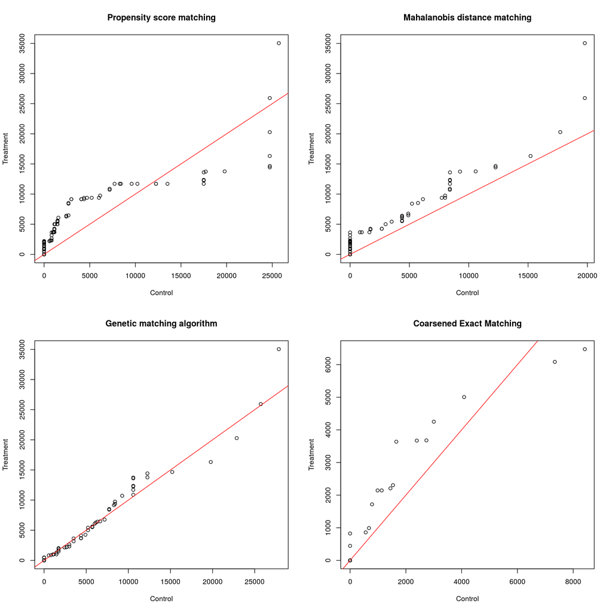

```r
par(mfrow = c(2,2))

qqplot(
  lalonde$re74[rr1$index.control],
  lalonde$re74[rr1$index.treated],
  main = "Propensity score matching",
  xlab = "Control",
  ylab = "Treatment"
)

abline(
  coef = c(0, 1),
  col = 2
)

qqplot(
  lalonde$re74[rr2$index.control],
  lalonde$re74[rr2$index.treated],
  main = "Mahalanobis distance matching",
  xlab = "Control",
  ylab = "Treatment"
)

abline(
  coef = c(0, 1),
  col = 2
)

qqplot(
  lalonde$re74[mgen1$index.control],
  lalonde$re74[mgen1$index.treated],
  main = "Genetic matching algorithm",
  xlab = "Control",
  ylab = "Treatment"
)

abline(
  coef = c(0, 1),
  col = 2
)

qqplot(
  X1 %>% dplyr::filter(mat$matched,treat == 0) %$% re74,
  X1 %>% dplyr::filter(mat$matched,treat == 1) %$% re74,
  main = "Coarsened Exact Matching",
  xlab = "Control",
  ylab = "Treatment"
)

abline(
  coef = c(0, 1),
  col = 2
)
```

# Reproducibility info

```r
.libPaths()
```

```
## [1] "/home/matthew/R/x86_64-pc-linux-gnu-library/3.3"
## [2] "/usr/local/lib/R/site-library"
## [3] "/usr/lib/R/site-library"
## [4] "/usr/lib/R/library"
```

# References

Sekhon, J. (2011). Multivariate and Propensity Score Matching Software with Automated Balance Optimization: The Matching Package for R. *Journal of statistical software*, 42, 7. Available at http://sekhon.berkeley.edu/papers/MatchingJSS.pdf